# eQTL B6 vs BXD references

Nastassia Gobet

2021-03-18

# Goal

Check overlap between eQTLs with mm9, mm10, and BXD-specific references and make a venn diagram.

- method 1: check markers (marker IDs)
- method 2: check if coordinates of markers matching even if different coordinates systems
- method 3: grouped eQTLs with reference as covariables

# Information

Doing this in default STAR setting (genotypesandimputed_withannotation_Local_0_10) because also available with B6 mm10 reference (abbreviated B6)

FastQTL output (http://fastqtl.sourceforge.net/):

- rowname = ID molecular phenotype (gene)
- V2 = number of variant tested
- V3 = MLE of shape 1 parameter of beta distribution
- V4 = MLE of shape 2 parameters of beta distribution
- V5 = to be described (not explained on FastQTL website)
- V6 = ID of best variant
- V7 = distance between variant and molecular phenotype
- V8 = p-value of association between variant and molecular phenotype
- V9 = slope of regression
- V10 = first permutation p-value accounting for multiple variants tested by molecular phenotype
- V11 = second permutation p-value obtained with beta approximation (recommended to use this one)

# Preparation

## Functions definitions

```r
prepareRawCounts <- function(counts, ref){

  # convert gene ids to gene names
  idx_uniq <- which(!duplicated(GeneConvert$V2[match(rownames(counts), GeneConvert$V1)]))
  counts <- counts[idx_uniq,]
  rownames(counts) <- GeneConvert$V2[match(rownames(counts), GeneConvert$V1)]

  # change X into C for cortex
  colnames(counts) <- gsub("X", "C", colnames(counts))
  # split by tissue and condition
  CortexNSD <- subset(counts, select=grep("^C[0-9]*nsd$", colnames(counts), value=TRUE))
  CortexSD <- subset(counts, select=grep("^C[0-9]*sd$", colnames(counts), value=TRUE))
  LiverNSD <- subset(counts, select=grep("^L[0-9]*nsd$", colnames(counts), value=TRUE))
  LiverSD <- subset(counts, select=grep("^L[0-9]*sd$", colnames(counts), value=TRUE))
  # clean and formate names of mouse lines
  colnames(CortexNSD) <- LinesNames$V5[match(gsub("[LCnsd]", "", colnames(CortexNSD)), LinesNames$V10)]
  colnames(CortexSD) <- LinesNames$V5[match(gsub("[LCnsd]", "", colnames(CortexSD)), LinesNames$V10)]
  colnames(LiverNSD) <- LinesNames$V5[match(gsub("[LCnsd]", "", colnames(LiverNSD)), LinesNames$V10)]
  colnames(LiverSD) <- LinesNames$V5[match(gsub("[LCnsd]", "", colnames(LiverSD)), LinesNames$V10)]

  # output 4 datasets
  assign(paste0("counts", ref, "ref_CortexNSD"), CortexNSD, envir=parent.frame())
  assign(paste0("counts", ref, "ref_CortexSD"), CortexSD, envir=parent.frame())
  assign(paste0("counts", ref, "ref_LiverNSD"), LiverNSD, envir=parent.frame())
  assign(paste0("counts", ref, "ref_LiverSD"), LiverSD, envir=parent.frame())
}

# plot gene expression for a pair gene-variant
plotGeneExpressionVariant <- function(ref, gene, variant, tissue, condition){
  # get first letter of tissue
   t <- unlist(strsplit(tissue, split=""))[1]
  # get gene expression dataset
  expr <- eval(parse(text=paste0("expr", ref, "ref", t, condition)))
  # plot
  plot(as.numeric(expr[gene, sort(names(expr))]), pch=19, col=as.factor(genotypesGN[genotypesGN$Locus==variant, sort(names(expr))]), main=paste0("Gene: ", gene,", ref: ", ref, ", variant: ", variant, ", tissue: ", tissue, ", condition: ", condition), xaxt="n", xlab="", ylab="gene expression", las=1)
  axis(1, 1:length(names(expr)), sort(names(expr)), las=2)
}
# vectorize function
plotGeneExpressionVariant <- Vectorize(plotGeneExpressionVariant, SIMPLIFY=FALSE)
```

## Data preparation

```r
# load table to convert mouse line names
LinesNames <- read.table("F:/BXD/data/ConvertLineNames.tsv", header=FALSE, stringsAsFactors=FALSE, sep="\t")

# load table to convert between gene id and gene name
GeneConvert <- read.table("F:/BXD/references/gene_names_B6mm10.tab", header=FALSE, stringsAsFactors=FALSE, sep="\t")

# retrieve GeneNetwork (GN) genotypes
genotypesGN <- read.table("F:/BXD/data/genome/BXDGenotypes.geno", header=TRUE)

# retrieve eQTL results
for(tissue in c("Cortex", "Liver")){
  t <- unlist(strsplit(tissue, split=""))[1]
  for(condition in c("NSD", "SD")){
    assign(paste0("dataB6", t, condition), read.table(paste0("F:/BXD/data/transcriptome/eQTL_B6mm10primaryassembly_withannotation/TMMnormalized_log2CPM_", tissue, "_", condition, "_pvalcorrected.txt"), row.names=1, stringsAsFactors=FALSE))
    assign(paste0("dataB6full", t, condition), read.table(paste0("F:/BXD/data/transcriptome/eQTL_B6mm10primaryassembly_withannotation/TMMnormalized_log2CPM_", tissue, "_", condition, ".txt"), row.names=1, stringsAsFactors=FALSE))
    assign(paste0("dataBXD", t, condition), read.table(paste0("F:/BXD/data/transcriptome/eQTL_BXDfromGNandimputedD2blocks_withannotation/TMMnormalized_log2CPM_", tissue, "_", condition,"_pvalcorrected.txt"), row.names=1, stringsAsFactors=FALSE))
    assign(paste0("dataBXDfull", t, condition), read.table(paste0("F:/BXD/data/transcriptome/eQTL_BXDfromGNandimputedD2blocks_withannotation/TMMnormalized_log2CPM_", tissue, "_", condition, ".txt"), row.names=1, stringsAsFactors=FALSE))
  }
}

# retrieve gene expression
exprB6refCNSD <- read.table("F:/BXD/data/transcriptome/2_mapping_STAR/OnGenomeAndAnnotation/B6mm10primaryassembly_withannotation/TMMnormalized_log2CPM_Cortex_NSD.tab")
exprBXDrefCNSD <- read.table("F:/BXD/data/transcriptome/2_mapping_STAR/OnGenomeAndAnnotation/BXDfromGNandimputedD2blocks_withannotation/TMMnormalized_log2CPM_Cortex_NSD.tab")
exprB6refCSD <- read.table("F:/BXD/data/transcriptome/2_mapping_STAR/OnGenomeAndAnnotation/B6mm10primaryassembly_withannotation/TMMnormalized_log2CPM_Cortex_SD.tab")
exprBXDrefCSD <- read.table("F:/BXD/data/transcriptome/2_mapping_STAR/OnGenomeAndAnnotation/BXDfromGNandimputedD2blocks_withannotation/TMMnormalized_log2CPM_Cortex_SD.tab")
exprB6refLNSD <- read.table("F:/BXD/data/transcriptome/2_mapping_STAR/OnGenomeAndAnnotation/B6mm10primaryassembly_withannotation/TMMnormalized_log2CPM_Liver_NSD.tab")
exprBXDrefLNSD <- read.table("F:/BXD/data/transcriptome/2_mapping_STAR/OnGenomeAndAnnotation/BXDfromGNandimputedD2blocks_withannotation/TMMnormalized_log2CPM_Liver_NSD.tab")
exprB6refLSD <- read.table("F:/BXD/data/transcriptome/2_mapping_STAR/OnGenomeAndAnnotation/B6mm10primaryassembly_withannotation/TMMnormalized_log2CPM_Liver_SD.tab")
exprBXDrefLSD <- read.table("F:/BXD/data/transcriptome/2_mapping_STAR/OnGenomeAndAnnotation/BXDfromGNandimputedD2blocks_withannotation/TMMnormalized_log2CPM_Liver_SD.tab")
```

```r
# load mm9 cis-eQTL
ceLNSD_mm9 <- read.table("F:/BXD/BACKUP/mm9/Data/IntermediateLayer/cis-eQTL/Liver_nsd/ciseQTL.Liver.NSD.pvalcorrected.txt",sep='')
ceLSD_mm9 <- read.table("F:/BXD/BACKUP/mm9/Data/IntermediateLayer/cis-eQTL/Liver_sd/ciseQTL.Liver.SD.pvalcorrected.txt",sep='')
ceCNSD_mm9 <- read.table("F:/BXD/BACKUP/mm9/Data/IntermediateLayer/cis-eQTL/Cortex_nsd/ciseQTL.Cortex.NSD.pvalcorrected.txt",sep='')
ceCSD_mm9 <- read.table("F:/BXD/BACKUP/mm9/Data/IntermediateLayer/cis-eQTL/Cortex_sd/ciseQTL.Cortex.SD.pvalcorrected.txt",sep='')
# load mm10 cis-eQTL
ceLNSD_mm10 <- read.table("F:/BXD/BACKUP/mm10/Data/IntermediateLayer/cis-eQTL/ciseQTL.Liver.NSD.pvalcorrected.txt",sep='')
ceLSD_mm10 <- read.table("F:/BXD/BACKUP/mm10/Data/IntermediateLayer/cis-eQTL/ciseQTL.Liver.SD.pvalcorrected.txt",sep='')
ceCNSD_mm10 <- read.table("F:/BXD/BACKUP/mm10/Data/IntermediateLayer/cis-eQTL/ciseQTL.Cortex.NSD.pvalcorrected.txt",sep='')
ceCSD_mm10 <- read.table("F:/BXD/BACKUP/mm10/Data/IntermediateLayer/cis-eQTL/ciseQTL.Cortex.SD.pvalcorrected.txt",sep='')
```

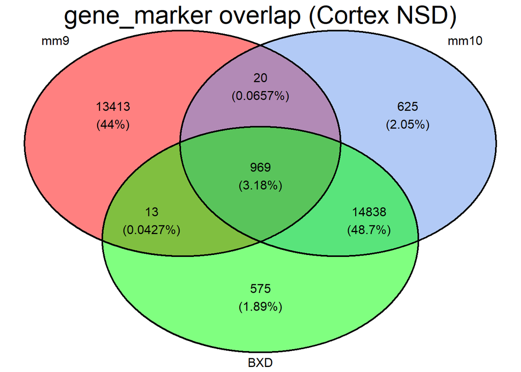

```r
# gene expression
exprB6refCNSD <- read.table("F:/BXD/data/transcriptome/2_mapping_STAR/OnGenomeAndAnnotation/B6mm10primaryassembly_withannotation/TMMnormalized_log2CPM_Cortex_NSD.tab")
exprBXDrefCNSD <- read.table("F:/BXD/data/transcriptome/2_mapping_STAR/OnGenomeAndAnnotation/BXDfromGNandimputedD2blocks_withannotation/TMMnormalized_log2CPM_Cortex_NSD.tab")

# eQTLs
ceCNSD_mm9 <- read.table("F:/BXD/BACKUP/mm9/Data/IntermediateLayer/cis-eQTL/Cortex_nsd/ciseQTL.Cortex.NSD.pvalcorrected.txt",sep='')
ceCNSD_mm10K <- read.table("F:/BXD/BACKUP/mm10/Data/IntermediateLayer/cis-eQTL/ciseQTL.Cortex.NSD.pvalcorrected.txt",sep='')
ceCNSD_mm10 <- read.table(paste0("F:/BXD/data/transcriptome/eQTL_B6mm10primaryassembly_withannotation/TMMnormalized_log2CPM_", "Cortex", "_", "NSD", "_pvalcorrected.txt"), row.names=1, stringsAsFactors=FALSE)
ceCNSD_BXD <- read.table(paste0("F:/BXD/data/transcriptome/eQTL_BXDfromGNandimputedD2blocks_withannotation/TMMnormalized_log2CPM_", "Cortex", "_", "NSD", "_pvalcorrected.txt"), row.names=1, stringsAsFactors=FALSE)

# remove genes with marker NA

ceCNSD_mm9_noNA <- ceCNSD_mm9[which(!is.na(ceCNSD_mm9$marker)), ]
ceCNSD_mm10K_noNA <- ceCNSD_mm10K[which(!is.na(ceCNSD_mm10K$marker)), ]
ceCNSD_mm10_noNA <- ceCNSD_mm10[which(!is.na(ceCNSD_mm10$marker)), ]
ceCNSD_BXD_noNA <- ceCNSD_BXD[which(!is.na(ceCNSD_BXD$marker)), ]

#############

ceCNSD_mm9_gene_eQTL <- paste(rownames(ceCNSD_mm9_noNA), ceCNSD_mm9_noNA$marker, sep="_")
ceCNSD_mm10_gene_eQTL <- paste(rownames(ceCNSD_mm10_noNA), ceCNSD_mm10_noNA$marker, sep="_")
ceCNSD_mm10K_gene_eQTL <- paste(rownames(ceCNSD_mm10K_noNA), ceCNSD_mm10K_noNA$marker, sep="_")
ceCNSD_BXD_gene_eQTL <- paste(rownames(ceCNSD_BXD_noNA), ceCNSD_BXD_noNA$marker, sep="_")

venn.plot <- venn.diagram(
  x = list(mm9=ceCNSD_mm9_gene_eQTL, mm10=ceCNSD_mm10_gene_eQTL, BXD=ceCNSD_BXD_gene_eQTL),
  filename = NULL,
  main="gene_marker overlap (Cortex NSD)",
  fontfamily="sans",
  main.fontfamily="sans",
  main.cex=2,
  cat.fontfamily="sans",
  print.mode = c("raw", "percent"),
  fill = c("red", "cornflowerblue", "green"),
  alpha = 0.50
);

grid.draw(venn.plot)
```

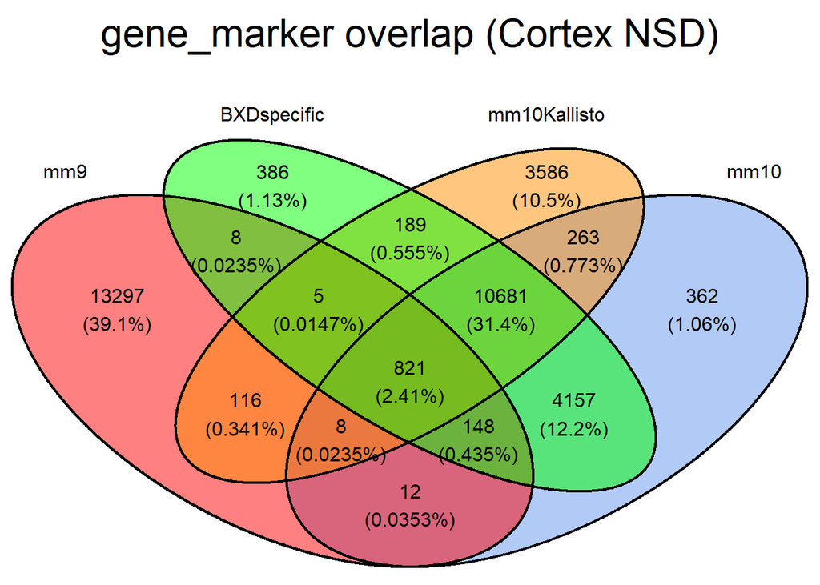

```r
venn.plot <- venn.diagram(
  x = list(mm9=ceCNSD_mm9_gene_eQTL, mm10=ceCNSD_mm10_gene_eQTL, BXDspecific=ceCNSD_BXD_gene_eQTL, mm10Kallisto=ceCNSD_mm10K_gene_eQTL),
  filename = NULL,
  main="gene_marker overlap (Cortex NSD)",
  fontfamily="sans",
  main.fontfamily="sans",
  main.cex=2,
  cat.fontfamily="sans",
  print.mode=c("raw", "percent"),
  fill = c( "red", "cornflowerblue", "green", "darkorange"),
  alpha = 0.50
);

grid.draw(venn.plot)
```